# 基于氧化应激相关基因的急性肝损伤机器学习诊断模型

计算生物学与人工智能课程项目

2026-09-13

# 1 背景与目的

对乙酰氨基酚(Acetaminophen, APAP)过量是急性肝衰竭(ALF)最主要的药物性病因,其核心机制为:过量 NAPQI 耗竭谷胱甘肽(GSH)→ 线粒体活性氧(ROS)爆发 → 肝细胞大面积坏死,**氧化应激居于致病中心**。

本项目基于 GEO 公共转录组数据,回答一个问题:**能否用少数氧化应激相关基因,构建一个跨平台、跨实验室依然有效的急性肝损伤诊断模型?**

技术路线:差异表达分析 → 氧化应激基因集取交集(OS-DEGs)→ 功能富集 → LASSO/随机森林/XGBoost 建模 → 独立数据集外部验证 → 跨物种方向一致性检验。全流程在 Linux(WSL2 Ubuntu)下以脚本完成,一键可复现。

# 2 数据与方法

## 2.1 数据

本研究所用数据集

| 角色 | 数据集 | 物种 | 设计 | 平台 | n |
| --- | --- | --- | --- | --- | --- |
| 训练集 | GSE17649 | 小鼠 | 多品系 APAP 后 0h vs 3–6h(12:24) | GPL1261 芯片 | 36 |
| 外部验证集 | GSE111828 | 小鼠 | C57BL/6J 未处理 vs APAP 12–72h(4:20) | RNA-seq(supplementary) | 24 |
| 跨物种方向验证 | GSE120652 | 人 | APAP-ALF vs 正常肝 | GPL6244 芯片 | 6 |

训练集 GSE17649 含敏感品系与抗性品系 SJL,对照为 **APAP 给药后 0h 基线**,不是溶媒/未处理对照。外部验证 GSE111828 与训练集为**同物种(小鼠)、不同平台**(芯片 vs RNA-seq)。

## 2.2 方法

1. **预处理**:GEO series matrix / 补充数据读取,必要时 log2 转换;探针注释由 GPL annot.gz 自动生成。
2. **差异表达**:limma(APAP vs Control,|log2FC|>1 且 BH adj.P<0.05)。
3. **OS-DEGs**:DEGs 与 GO:0006979(response to oxidative stress)基因集(EBI GOA 直接注释)取交集。
4. **富集**:clusterProfiler + org.Mm.eg.db,GO BP 与 KEGG。查询集来自氧化应激基因交集,GO:0006979 显著是筛选的必然结果,不作独立发现。
5. **机器学习**:OS-DEG 基因表达为特征;glmnet(LASSO)、randomForest、xgboost;分层 5 折 × 5 次重复交叉验证。折内对特征做 z-score,测试折使用训练集的均值与标准差。OS-DEGs 在全训练集上选出,故 CV AUC 略偏乐观,以外部验证为确认指标。
6. **外部验证**:验证集基因**独立** z-score(不套用芯片尺度)后输入模型;报告 AUC,以及阈值 0.5 下的灵敏度/特异度。
7. **跨物种检验**:小鼠 OS-DEGs 映射人源同源基因(符号直配),检验 log2FC 方向一致性。人源 n=6,仅作探索性附录。

所有脚本位于 `scripts/`,随机种子固定为 20260909。项目根目录由脚本自动解析,不再写死本机路径。

# 3 结果

## 3.1 差异表达分析

训练集 GSE17649(12 Control vs 24 APAP)与氧化应激基因集取交集后得到 **12 个探针 / 8 个基因**的 OS-DEGs:

OS-DEGs 列表(按 |logFC| 排序)

|  | 基因 | logFC | adjP |
| --- | --- | --- | --- |
| Hmox1 | Hmox1 | 3.83 | 0.00e+00 |
| Srxn1 | Srxn1 | 2.61 | 4.20e-06 |
| Btg1 | Btg1 | 1.89 | 2.51e-04 |
| Rcan1 | Rcan1 | 1.49 | 1.00e-04 |
| Xpa | Xpa | -1.44 | 3.79e-03 |
| Gclc | Gclc | 1.42 | 4.22e-04 |
| Itch | Itch | -1.18 | 7.56e-05 |
| Txnrd1 | Txnrd1 | 1.06 | 1.74e-03 |

值得注意的是,**Hmox1、Srxn1、Gclc、Txnrd1 均为 Nrf2 通路的经典靶基因**——Nrf2 通路激活正是细胞对抗氧化应激的核心应答,与 APAP 肝损伤的病理机制高度吻合。

## 3.2 功能富集

GO BP 富集前 5 位通路(含筛选条目,仅供对照)

| ID | Description | GeneRatio | FoldEnrichment | p.adjust |
| --- | --- | --- | --- | --- |
| GO:0006979 | response to oxidative stress | 8/8 | 39.841 | 0.000 |
| GO:0045454 | cell redox homeostasis | 2/8 | 140.819 | 0.015 |
| GO:0009636 | response to toxic substance | 3/8 | 27.718 | 0.015 |
| GO:0046685 | response to arsenic-containing substance | 2/8 | 110.372 | 0.015 |
| GO:0046686 | response to cadmium ion | 2/8 | 85.078 | 0.020 |

```
## KEGG 显著通路(q<0.25)共 23 条,前 3 位:Ferroptosis；Hepatocellular carcinoma；Selenocompound metabolism
```

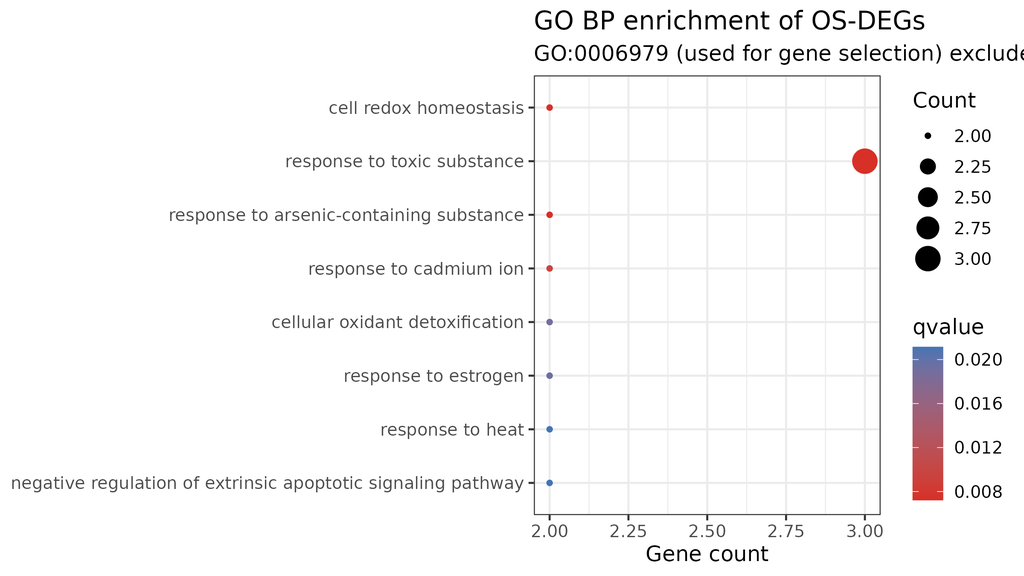

OS-DEGs 的 GO 富集点图(已排除筛选所用 GO:0006979)

最显著条目即为筛选所用的 **“response to oxidative stress”** 本身,这是基因集定义的循环结果,不能当作独立生物学发现。其余条目(如 cell redox homeostasis)可作为辅助描述。

## 3.3 机器学习诊断模型

以 8 个 OS-DEG 基因的表达为特征,三种模型的分层 5 折 × 5 次交叉验证结果:

训练集交叉验证 AUC(均值±标准差)

| model | auc_mean | auc_sd |
| --- | --- | --- |
| LASSO | 0.9271 | 0.0055 |
| randomForest | 0.9538 | 0.0112 |
| XGBoost | 0.9528 | 0.0119 |

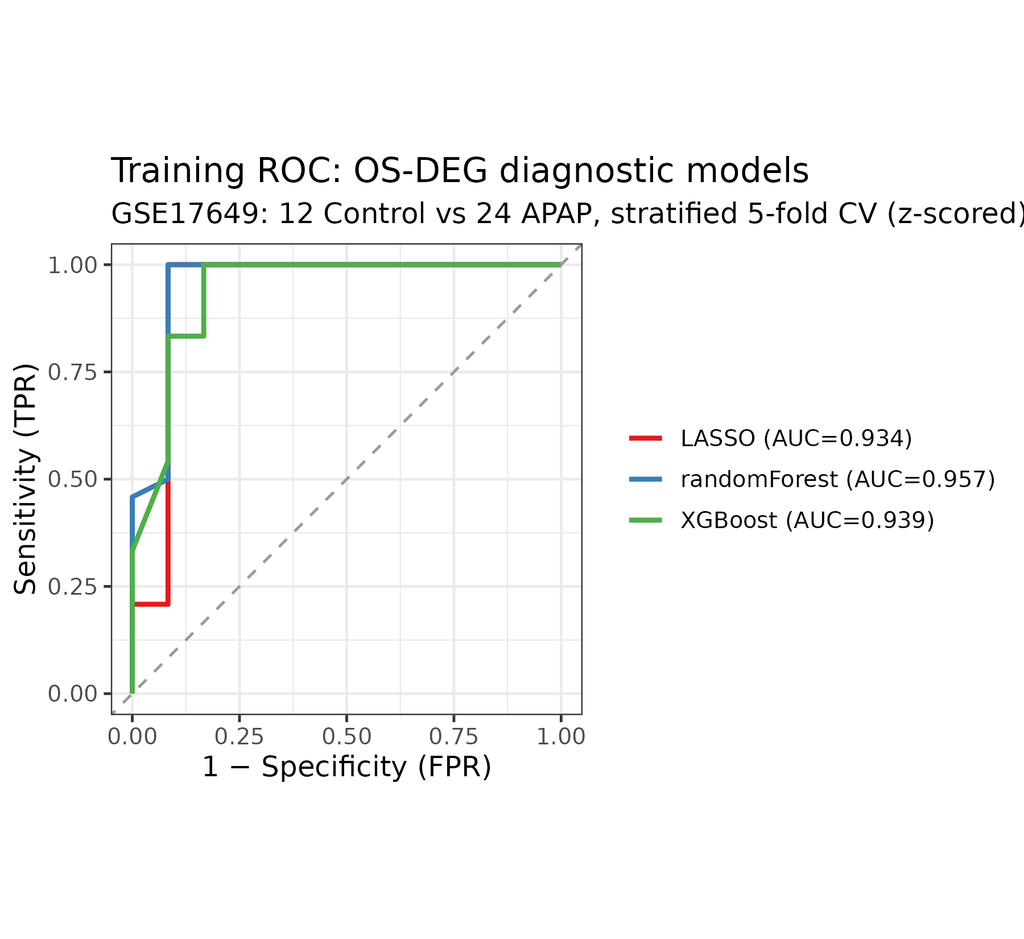

训练集 ROC 曲线

LASSO 将模型压缩至 **4 个基因**(Hmox1、Itch、Rcan1、Btg1);随机森林重要性前三为 Hmox1、Srxn1、Itch。两种特征选择视角一致指向 Hmox1 为核心特征。

## 3.4 外部验证(GSE111828,独立小鼠 RNA-seq)

将训练好的模型应用于 24 个独立样本(4 Control vs 20 APAP;验证集内 z-score):

外部验证(AUC;若有列则含阈值 0.5 的灵敏度/特异度)

| model | auc | sens_0.5 | spec_0.5 |
| --- | --- | --- | --- |
| LASSO | 0.9750 | 0.70 | 1 |
| randomForest | 0.9562 | 0.70 | 1 |
| XGBoost | 0.9188 | 0.25 | 1 |

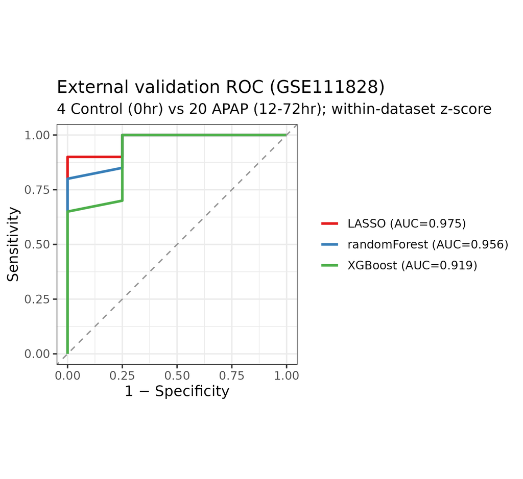

外部验证 ROC 曲线

验证集与训练集为**同种小鼠、不同实验与平台**。AUC 衡量排序能力;阈值 0.5 下的灵敏度/特异度用于检查概率是否校准。简约的 LASSO 若在外部验证中同时保持较高 AUC 与可用的特异度,才支持“跨平台分子签名”的说法。

## 3.5 跨物种方向一致性检验(人源数据,探索性)

人源 APAP-ALF 数据(GSE120652)中的方向一致性

| gene_symbol | mouse_logFC | logFC | adj.P.Val | direction_concordant |
| --- | --- | --- | --- | --- |
| GCLC | 1.42 | -1.04 | 0.196 | FALSE |
| TXNRD1 | 1.06 | 0.90 | 0.421 | TRUE |
| RCAN1 | 1.49 | -0.81 | 0.329 | FALSE |
| ITCH | -1.18 | -0.78 | 0.152 | TRUE |
| SRXN1 | 2.61 | 0.71 | 0.525 | TRUE |
| HMOX1 | 3.83 | 0.47 | 0.602 | TRUE |
| BTG1 | 1.89 | -0.31 | 0.474 | FALSE |
| XPA | -1.44 | -0.24 | 0.565 | TRUE |

```
## 方向一致:5/8;人源 BH 显著(adj.P<0.05):0/8
```

人源样本仅 6 例,校正后显著性弱,结果只用于讨论方向是否大致保留,不能称为跨物种验证成功。

# 4 讨论

1. **生物学合理性**:OS-DEGs 中 Hmox1/Gclc/Txnrd1/Srxn1 构成典型的 Nrf2 靶基因模块。已有文献报道 APAP 肝损伤中 Nrf2-HO1 轴的保护作用,与本项目的枢纽基因选择一致。GO:0006979 富集本身不能作为独立证据。
2. **模型简约性**:LASSO 从少数候选基因中再压缩,Hmox1 在两种特征选择方法中均靠前,可作为后续实验验证(如 qPCR、血清 HO-1 蛋白)的首选标志物。
3. **局限性**:训练集对照为给药后 0h 而非未处理肝,并混有抗性品系;OS-DEGs 在全训练集上选出,CV AUC 偏乐观;验证集对照仅 4 例,阈值分类的特异度可能不稳定;人源 n=6 且多数基因未过 FDR;未纳入临床协变量(ALT/AST 等)。

# 5 结论

少数氧化应激相关基因的表达可在小鼠芯片数据上拟合分类器,并在独立 RNA-seq 实验上检验排序能力。Hmox1 为最关键特征基因。将本模型直接外推到人类临床诊断尚缺乏充分证据。

# 6 复现说明

```bash
mamba env create -f env/rna.yml
conda activate rna
bash scripts/run_all.sh
```

数据下载、预处理、建模、验证全部由 `scripts/` 中编号脚本完成;随机种子固定。`env/rna.yml` 为 Linux-64 锁文件,换机器若创建失败,可在已有 R 4.x 环境中安装 limma、clusterProfiler、glmnet、randomForest、xgboost、pROC、ggplot2、rmarkdown、readxl 后直接跑脚本。

# 7 环境信息